[O’Hara on GitHub](https://github.com/oharac)

# Biodiversity risk and pct threatened four-panel figures

Compiled on Sat Aug 31 10:19:29 2019 by ohara

```r
knitr::opts_chunk$set(fig.path = 'figs/',
                      echo = TRUE, message = FALSE, warning = FALSE)

library(raster)
library(data.table)
library(sf)


source('https://raw.githubusercontent.com/oharac/src/master/R/common.R')  ###
  ### includes library(tidyverse); library(stringr); dir_M points to ohi directory

dir_git <- here()

source(file.path(dir_git, '_setup/common_fxns.R'))

### Gall-Peters doesn't have an EPSG?
gp_proj4 <- '+proj=cea +lon_0=0 +lat_ts=45 +x_0=0 +y_0=0 +ellps=WGS84 +units=m +no_defs'
```

# 1 Summary

A selection of these maps will be generated for taxonomic groups and range sizes in a separate Rmd.

# 2 Data sources

- IUCN species API: IUCN. (2019). The IUCN Red List of Threatened Species. Version 2019-2.
- IUCN species shapefiles: IUCN. (2019). The IUCN Red List of Threatened Species. Version 2019-2. Retrieved August 2019, from http://www.iucnredlist.org
- BirdLife International shapefiles: BirdLife International and Handbook of the Birds of the World. (2018). Bird species distribution maps of the world. Version 7.0. Available at http://datazone.birdlife.org/species/requestdis
- Marine Ecoregions of the World: Spalding, M. D., Fox, H. E., Allen, G. R., Davidson, N., Ferdaña, Z. A., Finlayson, M. A. X., … others. (2007). Marine ecoregions of the world: A bioregionalization of coastal and shelf areas. BioScience, 57(7), 573–583.

# 3 Methods

## 3.1 Spatial distribution of risk: comprehensively assessed spp

From the 1a and 1b biodiversity risk map scripts, gather the rasters for the various maps:

- Mean risk (unweighted and range-rarity-weighted)
- Pct threatened (unweighted and range-rarity-weighted)

```r
risk_un_rast   <- raster(file.path(dir_output, 'mean_risk_raster_comp.tif'))
risk_rr_rast   <- raster(file.path(dir_output, 'mean_rr_risk_raster_comp.tif'))
threat_un_rast <- raster(file.path(dir_output, 'pct_threat_raster_comp.tif'))
threat_rr_rast <- raster(file.path(dir_output, 'sr_rr_pct_threat_raster_comp.tif'))
n_spp_rast     <- raster(file.path(dir_output, 'n_spp_risk_raster_comp.tif'))
n_rr_rast      <- raster(file.path(dir_output, 'sr_rr_risk_raster_comp.tif'))
```

### 3.1.1 And now, the maps

```r
four_panel <- function(map1_rast, map2_rast,
                       limits = c(0, 1),
                       colors, values,
                       labels, breaks,
                       plot_labs = c('A', 'B')) {

  land_poly <- sf::read_sf(file.path(dir_spatial, 'ne_10m_land',
                                     'ne_10m_land_no_casp.shp')) %>%
    st_transform(gp_proj4)

  map_df <- data.frame(val_1 = values(map1_rast),
                       val_2 = values(map2_rast)) %>%
    cbind(coordinates(map1_rast)) %>%
    filter(!is.na(val_1))

  map1 <- ggplot(map_df) +
    geom_raster(aes(x, y, fill = val_1), show.legend = FALSE) +
    geom_sf(data = land_poly, aes(geometry = geometry),
            fill = 'grey96', color = 'grey40', size = .10) +
    ggtheme_map() +
    theme(plot.margin = unit(c(.05, 0, .1, .4), units = 'cm')) +
    coord_sf(datum = NA) + ### ditch graticules
    scale_fill_gradientn(colors = colors, values = values, limits = limits,
                         labels = labels, breaks = breaks,
                         guide  = guide_colourbar(label.position = 'left',
                                                  label.hjust = 1)) +
    scale_x_continuous(expand = c(0, 0)) +
    scale_y_continuous(expand = c(0, 0))

  map2 <- ggplot(map_df) +
    geom_raster(aes(x, y, fill = val_2), show.legend = FALSE) +
    geom_sf(data = land_poly, aes(geometry = geometry),
            fill = 'grey96', color = 'grey40', size = .10) +
    ggtheme_map() +
    theme(plot.margin = unit(c(.05, 0, .05, .4), units = 'cm')) +
    coord_sf(datum = NA) + ### ditch graticules
    scale_fill_gradientn(colors = colors, values = values, limits = limits,
                         labels = labels, breaks = breaks,
                         guide  = guide_colourbar(label.position = 'left',
                                                  label.hjust = 1)) +
    scale_x_continuous(expand = c(0, 0)) +
    scale_y_continuous(expand = c(0, 0))

  ###################

  ### set up a dataframe of values to craft a color bar using geom_segment
  colorbar_df <- data.frame(x = seq(0, 1, .001), y = -1)

  dens1 <- ggplot(map_df) +
    ggtheme_plot(base_size = 7) +
    geom_vline(xintercept = mean(map_df$val_1, na.rm = TRUE)) +
    geom_segment(data = colorbar_df,
                 aes(x = x, xend = x, color = x),
                 y = 0, yend = -10, size = 1,
                 show.legend = FALSE) +
    geom_density(aes(x = val_1, ..scaled..), alpha = .3, size = .25, fill = 'grey30') +
    scale_color_gradientn(colors = colors, values = values, limits = limits,
                          labels = labels, breaks = breaks) +
    theme(axis.text.x  = element_blank(),
          axis.title = element_blank(),
          panel.grid.major.x = element_blank(),
          plot.margin = unit(c(.5, .25, .5, .1), units = 'cm')) +
    scale_x_continuous(labels = labels, breaks = breaks, limits = limits,
                       expand = c(0, 0)) +
    scale_y_continuous(limits = c(-.4, 1)) +
    coord_flip()


  dens2 <- ggplot(map_df) +
    ggtheme_plot(base_size = 7) +
    geom_vline(xintercept = mean(map_df$val_2, na.rm = TRUE)) +
    geom_segment(data = colorbar_df,
                 aes(x = x, xend = x, color = x),
                 y = 0, yend = -10, size = 1,
                 show.legend = FALSE) +
    geom_density(aes(x = val_2, ..scaled..), alpha = .3, size = .25, fill = 'grey30') +
    scale_color_gradientn(colors = colors, values = values, limits = limits,
                          labels = labels, breaks = breaks) +
    theme(axis.text.x  = element_blank(),
          axis.title = element_blank(),
          panel.grid.major.x = element_blank(),
          plot.margin = unit(c(.5, .25, .5, .1), units = 'cm')) +
    scale_x_continuous(labels = labels, breaks = breaks, limits = limits,
                       expand = c(0, 0)) +
    scale_y_continuous(limits = c(-.4, 1)) +
    coord_flip()

  panel_top <- cowplot::plot_grid(map1, dens1,
                                  axis = 'b',
                                  rel_widths = c(5, 1))
  panel_btm <- cowplot::plot_grid(map2, dens2,
                                  axis = 'b',
                                  rel_widths = c(5, 1))

  four_panel <- cowplot::plot_grid(panel_top, panel_btm,
                                   labels = plot_labs,
                                   label_size = 9,
                                   nrow = 2, ncol = 1, align = 'v')

}
```

```r
### aggregate rasters for faster testing:
# risk_un_rast <- risk_un_rast %>% aggregate(10)
# risk_rr_rast <- risk_rr_rast %>% aggregate(10)

mean_four_panel <- four_panel(risk_un_rast, risk_rr_rast,
                              colors = risk_cols,
                              values = risk_vals,
                              labels = risk_lbls,
                              breaks = risk_brks,
                              plot_labs = c('A', 'C'))
```

```r
### aggregate rasters for faster testing:
# threat_un_rast <- threat_un_rast %>% aggregate(10)
# threat_rr_rast <- threat_rr_rast %>% aggregate(10)

threat_four_panel <- four_panel(threat_un_rast, threat_rr_rast,
                                colors = thr_cols,
                                values = thr_vals,
                                breaks = thr_brks,
                                labels = thr_lbls,
                                plot_labs = c('B', 'D'))
```

```r
four_maps <- cowplot::plot_grid(mean_four_panel, threat_four_panel,
                                nrow = 1, ncol = 2, align = 'v')

# fig1_path <- file.path(dir_git, 'ms_figures/fig1_comp_assessed.tiff')
fig1_path <- file.path(dir_git, 'ms_figures/fig1_comp_assessed.png')
ggsave(plot = four_maps,
       filename = fig1_path,
       width = 7.25, height = 3.7, units = 'in', dpi = 300)
```

### 3.1.2 Fig 1: Biodiversity risk and threatened species: comprehensively assessed spp

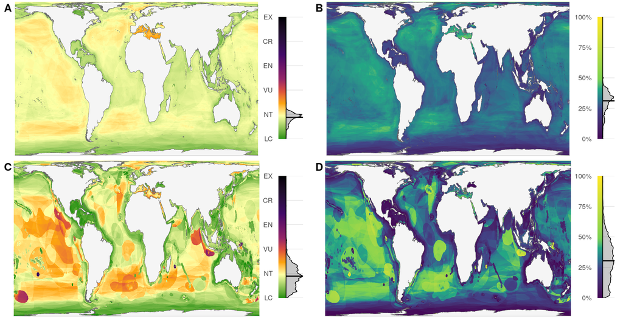

```r
risk_un_rast    <- raster(file.path(dir_output,
                                    'mean_risk_raster_all.tif'))
risk_rr_rast    <- raster(file.path(dir_output,
                                    'mean_rr_risk_raster_all.tif'))
threat_un_rast  <- raster(file.path(dir_output,
                                    'pct_threat_raster_all.tif'))
threat_rr_rast  <- raster(file.path(dir_output,
                                    'sr_rr_pct_threat_raster_all.tif'))
n_spp_rast <- raster(file.path(dir_output,
                               'n_spp_risk_raster_all.tif'))
n_rr_rast  <- raster(file.path(dir_output,
                               'sr_rr_risk_raster_all.tif'))
```

```r
### aggregate rasters for faster testing:
# risk_un_rast <- risk_un_rast %>% aggregate(10)
# risk_rr_rast <- risk_rr_rast %>% aggregate(10)

mean_four_panel <- four_panel(risk_un_rast, risk_rr_rast,
                              colors = risk_cols,
                              values = risk_vals,
                              labels = risk_lbls,
                              breaks = risk_brks,
                              plot_labs = c('A', 'C'),
                              label_size = 9)
```

```r
### aggregate rasters for faster testing:
# threat_un_rast <- threat_un_rast %>% aggregate(10)
# threat_rr_rast <- threat_rr_rast %>% aggregate(10)

threat_four_panel <- four_panel(threat_un_rast, threat_rr_rast,
                                colors = thr_cols,
                                values = thr_vals,
                                breaks = thr_brks,
                                labels = thr_lbls,
                                plot_labs = c('B', 'D'),
                                label_size = 9)
```